# ApoE4 dose effects on serum metabolites

## Differential expression of metabolites per ApoE genotype

### Global test in AD

```r
global.test <- function(data) {
  gt <- globaltest::gt(E4dose ~ 1, E4dose ~ . - E4 - Diagnosis - target, data = data, standardize = TRUE)
  print(gt)
  covariates <- covariates(gt, sort = TRUE)
  res.gt <- extract(covariates) %>%
    sort() %>%
    p.adjust(, method = "FDR") %>%
    globaltest::result() %>%
    mutate(across(where(is.numeric), \(x) round(x, digits = 3)))

  res.gt$direction <- as.factor(res.gt$direction)
  levels(res.gt$direction) <- c("no ApoE4", "1 ApoE4", "2 ApoE4")
  res.gt$alias <- NULL
  res.gt <- res.gt[, 1:4]
  names(res.gt) <- c("Inheritance", "Assoc. with", "FDR", "p-value")
  res.gt <- res.gt[, c(1:(ncol(res.gt) - 2), ncol(res.gt), (ncol(res.gt) - 1))]

  sig <- dplyr::filter(res.gt, `p-value` < 0.05)
  return(knitr::kable(sig, table.attr = "style='width:30%;'"))
}
```

Performing a Global Test of ApoE4 dose-effects, on serum metabolites of AD patients, correcting for sex (Ho: ApoE4 dose has no effect on mean metabolite levels, Ha: it has an effect), yields a significant difference (p = 0.0171). The most significantly affected metabolites are triglycerides and diglycerides (FDR-adjusted p-value <0.05).

```r
AD <- subset(df, Diagnosis == "Probable AD")
AD$E4dose <- as.factor(AD$E4dose)
global.test(AD)
```

```
  p-value Statistic Expected Std.dev #Cov
1  0.0171      1.23      0.8   0.168  232
```

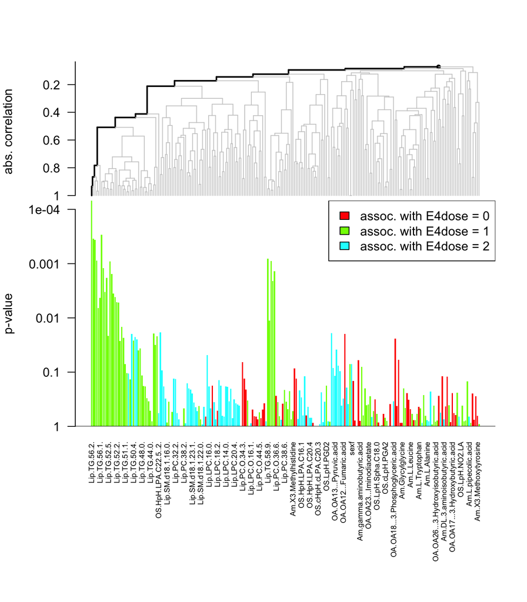

|  | Inheritance | Assoc. with | p-value | FDR |
| --- | --- | --- | --- | --- |
| Lip.TG.56.2. | 0.046 | 1 ApoE4 | 0.000 | 0.016 |
| Lip.TG.58.1. | 0.117 | 1 ApoE4 | 0.000 | 0.021 |
| Lip.DG.36.3. | 0.190 | 1 ApoE4 | 0.000 | 0.021 |
| Lip.TG.56.3. | 0.244 | 1 ApoE4 | 0.000 | 0.021 |
| Lip.TG.52.3. | 0.424 | 1 ApoE4 | 0.001 | 0.031 |
| Lip.TG.54.5. | 0.480 | 1 ApoE4 | 0.001 | 0.027 |
| Lip.TG.58.2. | 0.722 | 1 ApoE4 | 0.001 | 0.027 |
| Lip.TG.54.4. | 0.761 | 1 ApoE4 | 0.002 | 0.033 |
| Lip.TG.58.9. | 1.000 | 1 ApoE4 | 0.001 | 0.027 |
| Lip.TG.56.7. | 1.000 | 1 ApoE4 | 0.001 | 0.027 |
| Lip.TG.58.8. | 1.000 | 1 ApoE4 | 0.001 | 0.032 |
| Lip.TG.54.6. | 1.000 | 1 ApoE4 | 0.002 | 0.035 |
| Lip.TG.56.8. | 1.000 | 1 ApoE4 | 0.002 | 0.037 |
| Lip.TG.52.4. | 1.000 | 1 ApoE4 | 0.003 | 0.055 |
| Lip.TG.54.3. | 1.000 | 1 ApoE4 | 0.004 | 0.055 |
| Lip.TG.56.6. | 1.000 | 1 ApoE4 | 0.004 | 0.059 |
| Lip.TG.56.1. | 1.000 | 1 ApoE4 | 0.004 | 0.059 |
| Lip.TG.52.2. | 1.000 | 1 ApoE4 | 0.005 | 0.063 |
| Lip.TG.54.2. | 1.000 | 1 ApoE4 | 0.005 | 0.063 |
| Lip.TG.60.2. | 1.000 | 1 ApoE4 | 0.007 | 0.077 |
| Lip.TG.58.10. | 1.000 | 1 ApoE4 | 0.011 | 0.124 |
| Lip.TG.51.3. | 1.000 | 1 ApoE4 | 0.015 | 0.154 |
| Lip.SM.d18.1.18.1. | 1.000 | 2 ApoE4 | 0.018 | 0.169 |
| OA.OA09…2.ketoglutaric.acid | 1.000 | 2 ApoE4 | 0.019 | 0.169 |
| Lip.TG.52.0. | 1.000 | 1 ApoE4 | 0.019 | 0.169 |
| Lip.TG.50.3. | 1.000 | 2 ApoE4 | 0.020 | 0.169 |
| OA.OA29…Uracil | 1.000 | no ApoE4 | 0.020 | 0.169 |
| Lip.TG.52.5. | 1.000 | 1 ApoE4 | 0.021 | 0.174 |
| Lip.TG.54.0. | 1.000 | 1 ApoE4 | 0.022 | 0.174 |
| Lip.TG.50.2. | 1.000 | 2 ApoE4 | 0.022 | 0.174 |
| Lip.TG.51.2. | 1.000 | 1 ApoE4 | 0.023 | 0.174 |
| Am.L.Glutamine | 1.000 | no ApoE4 | 0.024 | 0.174 |
| Lip.TG.50.1. | 1.000 | 2 ApoE4 | 0.025 | 0.174 |
| Lip.TG.50.4. | 1.000 | 1 ApoE4 | 0.026 | 0.176 |
| Lip.TG.52.1. | 1.000 | 1 ApoE4 | 0.027 | 0.176 |
| Lip.TG.54.1. | 1.000 | 1 ApoE4 | 0.031 | 0.203 |
| Lip.TG.50.0. | 1.000 | 1 ApoE4 | 0.037 | 0.229 |
| OA.OA08…Malic.acid | 1.000 | 2 ApoE4 | 0.038 | 0.234 |
| Lip.DG.36.2. | 1.000 | 1 ApoE4 | 0.039 | 0.235 |
| OS.HpH.PAF.C16.0 | 1.000 | 2 ApoE4 | 0.049 | 0.283 |

### Global test in SCD

```r
SCD <- subset(df, Diagnosis == "Subjectieve klachten")
SCD$E4dose <- as.factor(SCD$E4dose)
global.test(SCD)
```

```
  p-value Statistic Expected Std.dev #Cov
1   0.544     0.789    0.847   0.225  232
```

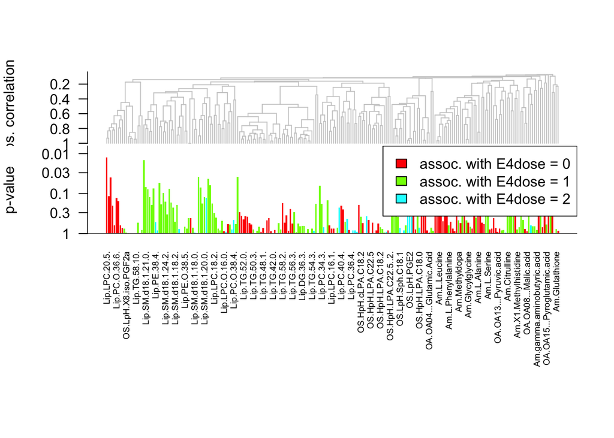

|  | Inheritance | Assoc. with | p-value | FDR |
| --- | --- | --- | --- | --- |
| Lip.LPC.20.5. | 1 | no ApoE4 | 0.012 | 0.828 |
| Lip.SM.d18.1.23.0. | 1 | 1 ApoE4 | 0.015 | 0.828 |
| Am.L.Tryptophan | 1 | no ApoE4 | 0.024 | 0.828 |
| Am.Putrescine | 1 | 1 ApoE4 | 0.028 | 0.828 |
| Am.Glycine | 1 | 1 ApoE4 | 0.035 | 0.828 |
| Lip.CE.18.2. | 1 | 1 ApoE4 | 0.038 | 0.828 |
| Lip.SM.d18.1.22.0. | 1 | 1 ApoE4 | 0.039 | 0.828 |
| OS.HpH.LPA.C20.5 | 1 | no ApoE4 | 0.040 | 0.828 |
| Lip.PC.36.3. | 1 | 1 ApoE4 | 0.043 | 0.828 |
| OA.OA11…Succinic.acid | 1 | 1 ApoE4 | 0.043 | 0.828 |
| Am.Citrulline | 1 | 1 ApoE4 | 0.043 | 0.828 |

### Nested Linear Models

Metabolite-level models to test for ApoE4 dose effects, correcting for age at diagnosis, sex, smoking status, alcohol consumption, hypertension (and medication), hyperlipidemia (and medication), anticoagulant medication, anti-depressants, mean arterial pressure (MAP) and body mass index (BMI). The F-tests yielded p-values < 0.05, however none of them survived FDR correction. Interestingly, in the SCD group, aminoacids were mostly affected and no TGs or DGs compared to the AD group.

```r
nested <- function(Y, x, ...) {
  ### Analysis of Variance (ANOVA)
  x <- as.factor(x)
  df <- cbind(Y, x, ...)
  ncol <- ncol(Y)
  covariates <- names(...)
  F_tests <- furrr::future_map(df[, 1:ncol], ~ {
    frm <- as.formula(paste0(".x ~", paste(covariates, collapse = "+")))
    rm <- lm(frm, data = df)
    ffm <- as.formula(paste0(".x ~ x +", paste(covariates, collapse = "+")))
    fm <- lm(ffm, data = df)
    anova(rm, fm)
  })
  # Correction for Multiple Testing
  # Extract the p-values of the F-tests from the anova summaries list and store them in p_values
  p_values <- F_tests %>%
    future_map(~.x[["Pr(>F)"]][[2]])
  # Coerce p_values to dataframe and transpose it
  p_values <- as.data.frame(p_values) %>%
    t() %>%
    data.frame(row.names = colnames(Y))
  # Calculate the FDR-adjusted p-values
  p_values$p_adj <- p.adjust(p_values[, ], method = "fdr", n = 230)
  p_values <- round(p_values, 3)
  # Filter out the non-significant (a=0.05) FDR-adjusted p-values
  sig <- as.data.frame(dplyr::filter(p_values, `.` < 0.05))
  sig <- sig[order(sig$p_adj), ]
  names(sig) <- c("P(>F)", "FDR")
  # cat("Significant F-tests: \n")
  # print(sig)
  # cat("\nDose effects on metabolites:")
  summaries <- furrr::future_map(df[, rownames(sig)], ~ {
    f <- as.formula(paste0(".x ~ x +", paste(covariates, collapse = "+")))
    mdl <- lm(f, data = df)
    summary(mdl)$coefficients[1:length(table(x)), ]
  })
  summaries <- lapply(summaries, function(x) {
    x <- x[, -c(2, 3)]
    x <- t(x)
  })
  summaries <- plyr::ldply(summaries, id = 1:2) %>%
    mutate(across(where(is.numeric), \(x) round(x, digits = 3)))
  coeffs <- summaries[c(TRUE, FALSE), ]
  pvalues <- summaries[c(FALSE, TRUE), ]
  t_tests <- cbind.data.frame(coeffs[, 1], coeffs[, 2], pvalues[, 2], coeffs[, 3], pvalues[, 3], coeffs[, 4], pvalues[, 4])
  names(t_tests) <- c("Metabolite", "No ApoE4", "P(>t)", "ApoE4x1", "P(>t)", "ApoE4x2", "P(>t)")
  sig <- cbind.data.frame(sig, t_tests)
  sig[, 3] <- NULL
  return(knitr::kable(sig, table.attr = "style='width:30%;'"))
}
```

```r
Y <- df[, 1:230]
df$E4dose <- as.numeric(df$E4dose) -1
df$E4dose[df$E4dose == 0] <- "No ApoE4"
df$E4dose[df$E4dose == 1] <- "1 ApoE4"
df$E4dose[df$E4dose == 2] <- "2 ApoE4"
E4dose <- df$E4dose <- as.factor(df$E4dose)
```

### AD group

Among AD patients, ApoE4 dose seems to have positive effect on several triglycerides, diglycerides, putrescine, 2-ketoglutraric acid, lysophosphatidylcholine and oxydative stress compounds: HpH.PAF.C16.0 and HpH.LPA.C18.0

```r
AD <- subset(df, Diagnosis == "Probable AD")
ADY <- AD[, 1:230]
ADE4dose <- AD$E4dose
ADclinical <- clinical[df$Diagnosis == "Probable AD",]

## Testing for effects of ApoE4 dose
nested(ADY, relevel(ADE4dose, ref= "No ApoE4"), ADclinical)
```

|  | P(>F) | FDR | No ApoE4 | P(>t) | ApoE4x1 | P(>t) | ApoE4x2 | P(>t) |
| --- | --- | --- | --- | --- | --- | --- | --- | --- |
| Lip.TG.52.3. | 0.001 | 0.156 | -1.443 | 0.818 | 2.568 | 0.004 | 3.719 | 0.001 |
| Lip.TG.52.4. | 0.003 | 0.156 | 0.620 | 0.888 | 1.628 | 0.008 | 2.392 | 0.002 |
| Lip.DG.36.3. | 0.002 | 0.156 | 0.026 | 0.631 | 0.019 | 0.012 | 0.031 | 0.001 |
| OS.HpH.PAF.C16.0 | 0.002 | 0.156 | 34.751 | 0.000 | 2.593 | 0.017 | 4.645 | 0.001 |
| Lip.TG.52.2. | 0.006 | 0.255 | -5.080 | 0.469 | 2.124 | 0.030 | 3.744 | 0.002 |
| Lip.TG.54.5. | 0.010 | 0.373 | 1.863 | 0.496 | 0.928 | 0.016 | 1.280 | 0.006 |
| Lip.TG.50.2. | 0.012 | 0.398 | -4.499 | 0.297 | 0.882 | 0.141 | 2.193 | 0.003 |
| Lip.TG.50.1. | 0.018 | 0.450 | -2.324 | 0.539 | 0.706 | 0.179 | 1.837 | 0.005 |
| Lip.TG.54.4. | 0.020 | 0.450 | 3.457 | 0.318 | 1.178 | 0.015 | 1.369 | 0.020 |
| Lip.TG.54.6. | 0.017 | 0.450 | -0.434 | 0.795 | 0.515 | 0.027 | 0.746 | 0.009 |
| Am.Putrescine | 0.029 | 0.515 | 0.004 | 0.000 | 0.000 | 0.035 | 0.000 | 0.017 |
| OA.OA09…2.ketoglutaric.acid | 0.026 | 0.515 | 0.008 | 0.366 | 0.000 | 0.953 | 0.003 | 0.014 |
| Lip.TG.50.3. | 0.028 | 0.515 | -1.203 | 0.668 | 0.594 | 0.127 | 1.268 | 0.008 |
| Lip.TG.52.5. | 0.042 | 0.538 | 0.459 | 0.789 | 0.358 | 0.134 | 0.725 | 0.014 |
| Lip.TG.56.7. | 0.042 | 0.538 | -2.394 | 0.095 | 0.487 | 0.015 | 0.392 | 0.105 |
| Lip.TG.56.8. | 0.044 | 0.538 | -1.393 | 0.055 | 0.248 | 0.014 | 0.175 | 0.151 |
| Lip.TG.58.9. | 0.042 | 0.538 | -0.447 | 0.068 | 0.085 | 0.013 | 0.034 | 0.410 |
| Lip.LPC.16.0. | 0.033 | 0.538 | 4.220 | 0.028 | 0.312 | 0.237 | 0.850 | 0.009 |
| OS.HpH.LPA.C18.0 | 0.044 | 0.538 | 0.498 | 0.038 | 0.044 | 0.178 | 0.101 | 0.013 |

### SCD group

```r
SCD <- df[df$Diagnosis == "Subjectieve klachten",]
SCDY <- SCD[, 1:230]
SCDE4dose <- SCD$E4dose
SCDclinical <- clinical[df$Diagnosis == "Subjectieve klachten",]

## Testing for effects of ApoE4 dose
nested(SCDY, relevel(SCDE4dose, ref= "No ApoE4"), SCDclinical)
```

|  | P(>F) | FDR | No ApoE4 | P(>t) | ApoE4x1 | P(>t) | ApoE4x2 | P(>t) |
| --- | --- | --- | --- | --- | --- | --- | --- | --- |
| Am.L.Serine | 0.002 | 0.285 | 4.669 | 0.000 | 0.191 | 0.115 | -1.058 | 0.003 |
| Am.L.Tryptophan | 0.002 | 0.285 | 3.747 | 0.004 | -0.307 | 0.047 | -1.364 | 0.002 |
| Am.Glycine | 0.006 | 0.450 | 4.332 | 0.001 | 0.382 | 0.015 | -0.873 | 0.052 |
| Am.L.homoserine | 0.047 | 0.931 | 0.003 | 0.001 | 0.000 | 0.723 | -0.001 | 0.014 |
| Am.Putrescine | 0.045 | 0.931 | 0.000 | 0.969 | 0.001 | 0.013 | 0.000 | 0.927 |
| Lip.SM.d18.1.22.0. | 0.043 | 0.931 | 3.337 | 0.002 | 0.309 | 0.015 | 0.272 | 0.448 |
| Lip.SM.d18.1.23.0. | 0.029 | 0.931 | 1.241 | 0.010 | 0.144 | 0.012 | 0.176 | 0.277 |